# TFM: Analysis

This document summarizes the analysis performed on the TFM titled “Association study of Val66Met *BDNF* polymorphism with eating and gambling disorders”.

This research project considers a population of patients diagnosed with eating disorders (EDs), specifically restrictive-type anorexia nervosa (AN-R), purging-type anorexia nervosa (AN-P) and bulimia nervosa (BN), and gambling disorder (GD), who were SNP-genotyped for the Val66Met *BDNF* polymorphism. Additionally, different psychometric measures were took from participants to quantify different psychological aspects (Table 1).

Table 1. Overview of psychometric instruments used in the study

Psychometric test

Measurement

Number of items

Dimensions

EDI-2: Eating Disorders Inventory 2

EDs screening

91

- Drive for thinness
- Body dissatisfaction
- Interoceptive awareness
- Bulimia
- Interpersonal distrust
- Ineffectiveness
- Maturity fears
- Perfectionism
- Impulse regulation
- Asceticism
- Social insecurity

SCL-90-R: Symptom Checklist 90

Psychological distress and general psychopathology

90

- Somatization
- Obsessive-compulsive
- Interpersonal sensitivity
- Depression
- Anxiety
- Hostility
- Phobic anxiety
- Paranoid ideation
- Psychoticism

TCI-R: Temperament and Character Inventory

Personality traits

240

- Novelty seeking
- Harm avoidance
- Reward dependence
- Persistence
- Self-directedness
- Cooperativity
- Self-transcendence

DSM-5 GD: Diagnostic Questionnaire for Gambling Disorder

GD screening

19

*No dimensions*

SOGS: South Oaks Gambling Screen

GD screening and severity assessment

20

*No dimensions*

The study aims to:

- Assess the association of Val66Met *BDNF* with EDs and GD as a transdiagnostic factor.
- Explore modulating factors for this interaction, such as psychopathology, clinical severity, etc.
- Analyze the association between Val66Met *BDNF* and treatment outcome in patients diagnosed with EDs (specifically AN and BN) or GD.

## Loading packages and data

The following packages will be loaded for posterior analyses.

```r
# Making a list of the packages
pckgs = c("ggplot2", "dplyr", "readxl", "gtsummary", "ggpubr", "rlang", "patchwork", "knitr", "lavaan", "sjPlot", "sjmisc")
# Loading the packages
invisible(lapply(pckgs, library, character.only = TRUE))
```

The dataset will be loaded and stored in an object named “trans”.

```r
# Loading the data
trans <- read_excel(path = "./base.xlsx", sheet = "trans")
```

## Preparing the dataset

Before conducting any analysis, data must be cleaned. In this case, some categorical variables are declared as such.

```r
trans <- trans %>%
  mutate(bdnf_val = factor(bdnf_val, levels = c("Met/Met", "Val/Met", "Val/Val"))) %>% # BDNF Val66Met possible genotypes
  mutate(bdnf_val2 = factor(bdnf_val2, levels = c("Val/Met or Met/Met", "Val/Val"))) %>% # BDNF Val66Met carrier status
  mutate(bdnf_27c = factor(bdnf_27c, levels = c("CC", "CT", "TT"))) %>%
  mutate(outcome = factor(outcome, levels = c("full remission",
                                              "partial remission",
                                              "non-remission/dropout"))) %>% # treatment outcome categorised in 3 levels
  mutate(outcome_2 = factor(outcome_2, levels = c("full remission",
                                                  "partial remission",
                                                  "non-remission", "dropout"))) %>% # treatment outcome categorised in 4 levels
  mutate(diagnosis = factor(diagnosis, levels = c("AN-R", "AN-P", "BN", "GD"))) %>% # diagnosis
  mutate(sex = factor(sex, levels = c("female", "male"))) %>% # sex
  mutate(est_civil = factor(est_civil, levels = c("single", "married", "divorced"))) %>% # civil status
  mutate(estudios = factor(estudios, levels = c("primarios", "graduado escolar",
                                                "bachillerato incompleto/fp1",
                                                "bachillerato completo/fp2",
                                                "universidad incompleta",
                                                "universidad completa",
                                                "máster-doctorado"))) # educational level

# Since educational level is categorised in many different groups, they will be classified into primary, secondary and superior studies
trans <- transform(trans, studies = ifelse(estudios %in% c("primarios","graduado escolar", "bachillerato incompleto/fp1"), "primary",
                                           ifelse(estudios %in% c("bachillerato completo/fp2", "universidad incompleta"), "secondary",
                                                  ifelse(estudios %in% c("universidad completa", "máster-doctorado"), "university", NA))))
```

Any possible outlier is also removed from the dataset (e.g., AN patient with BMI ≥ 18.5 kg/m<sup>2</sup>) or those individuals with high amount of missingness.

```r
trans <- trans[!(trans$diagnosis %in% c("AN-R", "AN-P") & trans$bmi >= 18.5) & # AN patients with normal weight
                 !trans$CASO %in% c(10263, 10441, 10723, 10735, 11000, 11452),] # individuals with high missingness
```

```r
# Severity index function
assign_severity <- function(df) {
  # For AN patients, divide them into the following categories provided by the DSM-5:
  # - mild: ≥ 17 kg/m²
  # - moderate: 16-17 kg/m²
  # - severe: 15-16 kg/m²
  # - extreme: < 15 kg/m²
  if (df["diagnosis"] %in% c("AN-R", "AN-P")) {
    if (!is.na(as.numeric(df["bmi"]))) {
      if (as.numeric(df["bmi"]) < 15) {
        return("extreme")
      } else if (as.numeric(df["bmi"]) >= 15 & as.numeric(df["bmi"]) < 16) {
        return("severe")
      } else if (as.numeric(df["bmi"]) >= 16 & as.numeric(df["bmi"]) < 17) {
        return("moderate")
      } else {
        return("mild")
      }
    }
  # For BN patients, divide them into the following categories provided by the DSM-5:
  # - mild: ≥ 3 vomits per week
  # - moderate: 4-7 vomits per week
  # - severe: 8-13 vomits per week
  # - extreme: > 13 vomits per week
  } else if (df["diagnosis"] == "BN") {
    if (!is.na(as.numeric(df["vomit_week"]))){
      if (as.numeric(df["vomit_week"]) > 13) {
        return("extreme")
      } else if (as.numeric(df["vomit_week"]) >= 8 & as.numeric(df["vomit_week"]) <= 13) {
        return("severe")
      } else if (as.numeric(df["vomit_week"]) >= 4 & as.numeric(df["vomit_week"]) <= 7) {
        return("moderate")
      } else if (as.numeric(df["vomit_week"]) >= 1 & as.numeric(df["vomit_week"]) <= 3) {
        return("mild")
      }
    }
  # For GD patients, divide them into the following categories provided by the DSM-5:
  # - mild: > 6 criteria
  # - moderate: > 8 criteria
  # - severe: > 10 criteria
  } else if (df["diagnosis"] == "GD") {
    if (!is.na(as.numeric(df["dsm_jp_crit"]))) {
      if (as.numeric(df["dsm_jp_crit"]) < 6) {
        return("mild")
      } else if (as.numeric(df["dsm_jp_crit"]) < 8) {
        return("moderate")
      } else if (as.numeric(df["dsm_jp_crit"]) < 10) {
        return("severe")
      }
    }
  }
  return(NA) # Return NA if no criteria match
}

# Apply function to dataframe
trans$severity <- apply(trans, 1, assign_severity)

# Define the order of the levels of severity
trans <- trans %>%
  mutate(severity = factor(severity, levels = c("mild", "moderate", "severe", "extreme")))
```

Color palettes will be used later for graphical representations. Below, there is a chunk of code to prepare them.

```r
# Genotype palette
genotypes <- c("#E63946", "#BA6A7C", "#8D99AE") # Met/Met: #E63946, Val/Met: #BA6A7C, Val/Val: 8D99AE
# Carrier palette
carriers <- c("#E63946", "#8D99AE") # carrier (Met/Met + Val/Met): #E63946, non-carrier (Val/Val): #8D99AE
# Severity palette
severity_scores <- c("#F8FA89", "#E9B569", "#DA6F4A", "#CB2A2A") # mild: #F8FA89, moderate: #E9B569, severe: #DA6F4A, extreme: #CB2A2A
# Outcome tetratomic palette
outcome_tetra <- c("#43A643", "#FFE373", "#AF3A3C", "#711313") # full remission: #43A643, partial remission: #FFE373, bad remission: #AF3A3C, dropout: #711313
# Outcome dichotomic palette
outcome_dicho <- c("#43A643", "#9CA642", "#AF3A3C", "#711313") # full remission: #AAAF3F, partial remission: #FFE373, bad remission: #AF3A3C, dropout: #711313
```

## Revising genotype frequencies

### Genotype frequencies

Genotype frequencies are checked.

```r
# Create the table for genotype frequencies
tbl <- table(trans$bdnf_val)
# Add the percentages
tbl <- cbind(tbl, paste0(round(tbl/sum(tbl)*100, 2), "%"))
# Generate a more elegant table
kable(tbl, col.names = c("Genotype", "Frequency", "Percentage"))
```

| Genotype | Frequency | Percentage |
| --- | --- | --- |
| Met/Met | 5 | 2.81% |
| Val/Met | 61 | 34.27% |
| Val/Val | 112 | 62.92% |

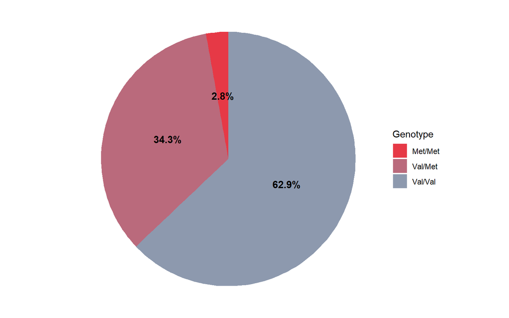

```r
data_summary <- trans %>%
  count(bdnf_val) %>% # Get the genotype frequencies
  mutate(Percentage = n / sum(n) * 100) %>% # Calculate the percentages
  ungroup() # Ungroup, so dplyr does not consider this for future analyses

ggplot(data_summary, aes(x = "", y = Percentage, fill = bdnf_val)) + # Consider the percentage of each genotype
  geom_bar(stat = "identity") + # Produce a bar plot
  coord_polar(theta = "y") + # Transform the bar plot into a pie chart
  geom_text(aes(label = paste0(round(Percentage, 1), "%"), fontface = "bold"),
            position = position_stack(vjust = 0.5), size = 4, color = "black") + # Add the percentages to the plot
  labs(fill = "Genotype") + # Name the legend's title as "Genotype frequencies"
  scale_fill_manual(values = genotypes) + # Color the pie chart with the color paletter for genotypes
  theme_void() # Make a void theme so it looks as clean as possible
```

### Carrier status frequencies

As there are only 5 individuals with Met/Met genotype, we can merge Met/Met and Val/Met individuals and differentiate groups by carrier or non-carriers.

```r
# Create the table for carrier status frequencies
tbl <- table(trans$bdnf_val2)
# Add the percentages
tbl <- cbind(tbl, paste0(round(tbl/sum(tbl)*100, 2), "%"))
# Generate a more elegant table
kable(tbl, col.names = c("Carrier status", "Frequency", "Percentage"))
```

| Carrier status | Frequency | Percentage |
| --- | --- | --- |
| Val/Met or Met/Met | 66 | 37.08% |
| Val/Val | 112 | 62.92% |

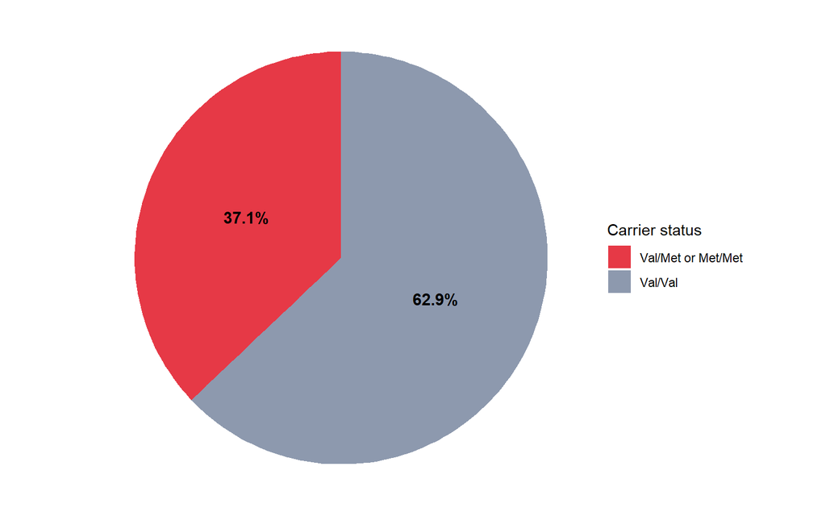

```r
data_summary <- trans %>%
  count(bdnf_val2) %>% # Get the carrier status frequencies
  mutate(Percentage = n / sum(n) * 100) %>% # Calculate the percentages
  ungroup() # Ungroup, so dplyr does not consider this for future analyses

ggplot(data_summary, aes(x = "", y = Percentage, fill = bdnf_val2)) + # Consider the percentage of the carriers
  geom_bar(stat = "identity") + # Produce a bar plot
  coord_polar(theta = "y") + # Transform the bar plot into a pie chart
  geom_text(aes(label = paste0(round(Percentage, 1), "%"), fontface = "bold"),
            position = position_stack(vjust = 0.5), size = 4, color = "black") + # Add the percentages to the plot
  labs(fill = "Carrier status") + # Name the legend's title as "Carrier status frequencies"
  scale_fill_manual(values = carriers) + # Color the pie chart with the color palette for carrier status
  theme_void() # Make a void theme so it looks as clean as possible
```

Given the low representation of AA individuals, for posterior analyses, two groups will be defined: Val/Val (homozygous wild-type) and Val66Met carriers (heterozygous and homozygous variant).

## Checking for normality

Given that some variables are continuous, normality must be checked in order to decide which statistical test to use.

```r
# Prepare a vector with the name of all psychometric dimensions so we can iterate through them
psych_dims <- c("Age", "Age of onset", "Duration", "BMI", "Vomits/week", "SOGS criteria", "EDI-2: Drive for thinness", "EDI-2: Body dissatisfaction", "EDI-2: Interoceptive awareness", "EDI-2: Bulimia", "EDI-2: Interpersonal distrust", "EDI-2: Ineffectiveness", "EDI-2: Maturity fears", "EDI-2: Perfectionism", "EDI-2: Impulse regulation", "EDI-2: Asceticism", "EDI-2: Social insecurity", "EDI-2 Total", "SCL-90-R: Somatization", "SCL-90-R: Obessive-compulsive", "SCL-90-R: Interpersonal sensitivity", "SCL-90-R: Depression", "SCL-90-R: Anxiety", "SCL-90-R: Hostility", "SCL-90-R: Phobic anxiety", "SCL-90-R: Paranoid ideation", "SCL-90-R: Psychoticism", "SCL-90-R: GSI", "SCL-90-R: PST", "SCL-90-R: PSDI", "TCI-R: Novelty seeking", "TCI-R: Harm avoidance", "TCI-R: Reward dependence", "TCI-R: Persistence", "TCI-R: Self-directedness", "TCI-R: Cooperativeness", "TCI-R: Self-transcendence")

# Select psychometric variables and only the totals (and exclude the validy)
psych_var <- c("age", "onset", "duration", "bmi", "vomit_week", "sogs_crit", setdiff(
  grep("^(scl|edi|tci)_[a-zA-Z]+_pre$", names(trans), value = TRUE),
  "tci_val_pre"))
# Prepare a list where plots are stored
plots <- list()

# For loop to iterate through psychometric variables and evaluate normality for each one
for (var in 1:length(psych_var)) { # continuous variables to check

  trans %>%
    group_by(bdnf_val2) %>% # separate by group
    rstatix::shapiro_test(!!sym(psych_var[var])) %>% # run a normality test on each of them
    # Kolmogorov??? ks.test
    print() # show the results

    p <- ggplot(trans, aes_string(x = psych_var[var], fill = "bdnf_val2")) + # select the psychometric variable and color the plot by carrier status
      geom_histogram(bins = 20, position = "identity") + # make a histogram
      facet_wrap(~bdnf_val2) + # separate the plots by carrier status (no overlap)
      labs(title = psych_dims[var], y = "Counts", fill = expression(paste(italic("BDNF"), "Val66Met"))) + # title for the plot, X and Y-axis and legend
      scale_fill_manual(values = carriers) + # Color the histograms with these specific colors
      theme_bw() + # black and white theme
      theme(axis.title.x = element_blank(), legend.position = "none") # Remove the legend

  # Store the plots into the list
  plots[[var]] <- p
}
```

```
## # A tibble: 2 × 4
##   bdnf_val2          variable statistic            p
##   <fct>              <chr>        <dbl>        <dbl>
## 1 Val/Met or Met/Met age          0.870 0.00000515
## 2 Val/Val            age          0.870 0.0000000181
```

```
## # A tibble: 2 × 4
##   bdnf_val2          variable statistic        p
##   <fct>              <chr>        <dbl>    <dbl>
## 1 Val/Met or Met/Met onset        0.831 6.26e- 7
## 2 Val/Val            onset        0.803 1.50e-10
## # A tibble: 2 × 4
##   bdnf_val2          variable statistic           p
##   <fct>              <chr>        <dbl>       <dbl>
## 1 Val/Met or Met/Met duration     0.907 0.000190
## 2 Val/Val            duration     0.898 0.000000655
## # A tibble: 2 × 4
##   bdnf_val2          variable statistic       p
##   <fct>              <chr>        <dbl>   <dbl>
## 1 Val/Met or Met/Met bmi          0.932 0.0226
## 2 Val/Val            bmi          0.938 0.00656
## # A tibble: 2 × 4
##   bdnf_val2          variable   statistic           p
##   <fct>              <chr>          <dbl>       <dbl>
## 1 Val/Met or Met/Met vomit_week     0.704 0.000000325
## 2 Val/Val            vomit_week     0.817 0.00000224
## # A tibble: 2 × 4
##   bdnf_val2          variable  statistic      p
##   <fct>              <chr>         <dbl>  <dbl>
## 1 Val/Met or Met/Met sogs_crit     0.971 0.655
## 2 Val/Val            sogs_crit     0.957 0.0458
## # A tibble: 2 × 4
##   bdnf_val2          variable   statistic       p
##   <fct>              <chr>          <dbl>   <dbl>
## 1 Val/Met or Met/Met edi_dt_pre     0.918 0.00885
## 2 Val/Val            edi_dt_pre     0.964 0.0883
## # A tibble: 2 × 4
##   bdnf_val2          variable   statistic       p
##   <fct>              <chr>          <dbl>   <dbl>
## 1 Val/Met or Met/Met edi_bd_pre     0.901 0.00266
## 2 Val/Val            edi_bd_pre     0.933 0.00386
## # A tibble: 2 × 4
##   bdnf_val2          variable   statistic      p
##   <fct>              <chr>          <dbl>  <dbl>
## 1 Val/Met or Met/Met edi_ia_pre     0.956 0.144
## 2 Val/Val            edi_ia_pre     0.962 0.0714
```

[output cut: 125 more lines]

```
## # A tibble: 2 × 4
##   bdnf_val2          variable    statistic     p
##   <fct>              <chr>           <dbl> <dbl>
## 1 Val/Met or Met/Met tci_sdt_pre     0.986 0.729
## 2 Val/Val            tci_sdt_pre     0.993 0.874
## # A tibble: 2 × 4
##   bdnf_val2          variable   statistic      p
##   <fct>              <chr>          <dbl>  <dbl>
## 1 Val/Met or Met/Met tci_ct_pre     0.961 0.0599
## 2 Val/Val            tci_ct_pre     0.985 0.325
## # A tibble: 2 × 4
##   bdnf_val2          variable    statistic      p
##   <fct>              <chr>           <dbl>  <dbl>
## 1 Val/Met or Met/Met tci_stt_pre     0.960 0.0529
## 2 Val/Val            tci_stt_pre     0.974 0.0530
```

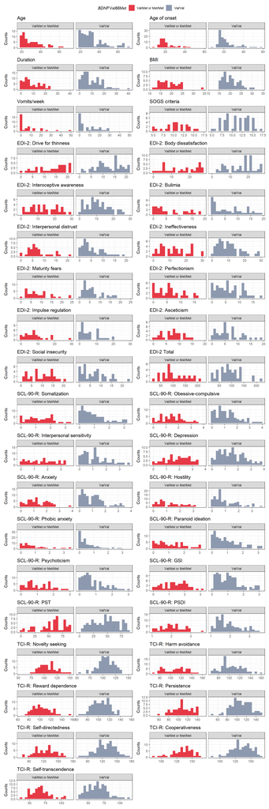

```r
final_plot <- (guide_area() / wrap_plots(plots, ncol = 2)) + # Combine all plots into a 2x6 layout
  plot_layout(heights = c(0.01, 1), guides = 'collect') & # Collect all legends and use just one
  theme(legend.position = "top") # Put the legend on top

final_plot
```

## Descriptive statistics

```r
# Having considered the distribution of the data, we can make a table for descriptive statistics
trans %>%
  select(diagnosis, sex, age, onset, duration, studies, est_civil, sit_lab, bdnf_val, bdnf_val2, outcome_2) %>% # consider diagnosis, sociodemographic and genteic variables
  tbl_summary(by = diagnosis, # divide by diagnosis
              missing = "no", # do not add missing counts
              statistic = all_continuous() ~ "{mean} ± {sd}, {median} ({p25}, {p75})", # for continuous variables, show them as mean ± SD, median (IQR)
              label = list(sex ~ "Sex", age ~ "Age (years)", onset ~ "Age of onset (years)", duration ~ "Duration (years)", studies ~ "Academical status", est_civil ~ "Civil status", sit_lab ~ "Professional status", bdnf_val ~ "BDNF Val66Met", bdnf_val2 ~ "Carrier status", outcome_2 ~ "Outcome")) %>% # Change variable names to a cleaner format
  add_n() %>% # Add the total number of observations
  add_p(test = list(all_continuous() ~ "kruskal.test", all_categorical() ~ "chisq.test")) %>% # for continuous variables run a Kruskal-Wallis test, for categorical variables run a Chi-squared test
  bold_labels() %>% # show in bold variable labels
  bold_p(t = 0.05) # show in bold p-values lower than 0.05
```

| **Characteristic** | **N** | **AN-R** N = 25<sup>1</sup> | **AN-P** N = 17<sup>1</sup> | **BN** N = 54<sup>1</sup> | **GD** N = 82<sup>1</sup> | **p-value**<sup>2</sup> |
| --- | --- | --- | --- | --- | --- | --- |
| Sex | 178 |  |  |  |  | <0.001 |
| female |  | 21 (84%) | 15 (88%) | 48 (89%) | 3 (3.7%) |  |
| male |  | 4 (16%) | 2 (12%) | 6 (11%) | 79 (96%) |  |
| Age (years) | 178 | 24 ± 7, 23 (19, 28) | 25 ± 5, 26 (20, 29) | 25 ± 5, 23 (21, 27) | 40 ± 12, 39 (31, 46) | <0.001 |
| Age of onset (years) | 167 | 19 ± 5, 18 (16, 20) | 19 ± 4, 18 (16, 22) | 18 ± 4, 18 (15, 20) | 26 ± 11, 22 (18, 33) | <0.001 |
| Duration (years) | 167 | 4 ± 4, 3 (1, 6) | 6 ± 5, 5 (2, 10) | 6 ± 4, 5 (4, 7) | 14 ± 8, 14 (7, 20) | <0.001 |
| Academical status | 178 |  |  |  |  | <0.001 |
| primary |  | 11 (44%) | 5 (29%) | 17 (31%) | 53 (65%) |  |
| secondary |  | 9 (36%) | 11 (65%) | 32 (59%) | 24 (29%) |  |
| university |  | 5 (20%) | 1 (5.9%) | 5 (9.3%) | 5 (6.1%) |  |
| Civil status | 176 |  |  |  |  | <0.001 |
| single |  | 20 (80%) | 14 (82%) | 47 (87%) | 22 (28%) |  |
| married |  | 5 (20%) | 3 (18%) | 6 (11%) | 47 (59%) |  |
| divorced |  | 0 (0%) | 0 (0%) | 1 (1.9%) | 11 (14%) |  |
| Professional status | 172 |  |  |  |  | 0.005 |
| active |  | 10 (43%) | 6 (40%) | 31 (58%) | 61 (75%) |  |
| inactive |  | 13 (57%) | 9 (60%) | 22 (42%) | 20 (25%) |  |
| BDNF Val66Met | 178 |  |  |  |  | 0.063 |
| Met/Met |  | 0 (0%) | 1 (5.9%) | 3 (5.6%) | 1 (1.2%) |  |
| Val/Met |  | 15 (60%) | 4 (24%) | 17 (31%) | 25 (30%) |  |
| Val/Val |  | 10 (40%) | 12 (71%) | 34 (63%) | 56 (68%) |  |
| Carrier status | 178 |  |  |  |  | 0.070 |
| Val/Met or Met/Met |  | 15 (60%) | 5 (29%) | 20 (37%) | 26 (32%) |  |
| Val/Val |  | 10 (40%) | 12 (71%) | 34 (63%) | 56 (68%) |  |
| Outcome | 178 |  |  |  |  | <0.001 |
| full remission |  | 14 (56%) | 11 (65%) | 27 (50%) | 34 (41%) |  |
| partial remission |  | 4 (16%) | 1 (5.9%) | 14 (26%) | 13 (16%) |  |
| non-remission |  | 3 (12%) | 3 (18%) | 13 (24%) | 3 (3.7%) |  |
| dropout |  | 4 (16%) | 2 (12%) | 0 (0%) | 32 (39%) |  |

<sup>1</sup> n (%); Mean ± SD, Median (Q1, Q3)  
<sup>2</sup> Pearson’s Chi-squared test; Kruskal-Wallis rank sum test

## Comparison across Val66Met variant groups

### Sociodemographic and clinical variables

```r
# Having considered the distribution of the data, we can make a table to compare based on the variant
trans %>%
  select(diagnosis, sex, age, onset, duration, studies, est_civil, sit_lab, bdnf_val2, outcome_2) %>% # consider diagnosis, sociodemographic and genetic variables
  tbl_summary(by = bdnf_val2, # divide by Val66Met variants groups
              missing = "no", # do not add missing counts
              statistic = all_continuous() ~ "{mean} ± {sd}, {median} ({p25}, {p75})", # for continuous variables, show them as mean ± SD, median (IQR)
              label = list(diagnosis ~ "Diagnosis", sex ~ "Sex", age ~ "Age (years)", onset ~ "Age of onset (years)", duration ~ "Duration (years)", studies ~ "Academical status", est_civil ~ "Civil status", sit_lab ~ "Professional status", outcome_2 ~ "Outcome")) %>% # Change variable names to a cleaner format
  add_n() %>% # Add the total number of observations
  add_p(test = list(all_continuous() ~ "wilcox.test", all_categorical() ~ "chisq.test")) %>% # for continuous variables run a Wilcoxon rank sum test, for categorical variables run a Chi-squared test
  bold_labels() %>% # show in bold variable labels
  bold_p(t = 0.05) # show in bold p-values lower than 0.05
```

| **Characteristic** | **N** | **Val/Met or Met/Met** N = 66<sup>1</sup> | **Val/Val** N = 112<sup>1</sup> | **p-value**<sup>2</sup> |
| --- | --- | --- | --- | --- |
| Diagnosis | 178 |  |  | 0.070 |
| AN-R |  | 15 (23%) | 10 (8.9%) |  |
| AN-P |  | 5 (7.6%) | 12 (11%) |  |
| BN |  | 20 (30%) | 34 (30%) |  |
| GD |  | 26 (39%) | 56 (50%) |  |
| Sex | 178 |  |  | 0.2 |
| female |  | 37 (56%) | 50 (45%) |  |
| male |  | 29 (44%) | 62 (55%) |  |
| Age (years) | 178 | 30 ± 11, 27 (21, 35) | 33 ± 13, 30 (23, 39) | 0.2 |
| Age of onset (years) | 167 | 21 ± 8, 18 (16, 22) | 23 ± 9, 19 (17, 25) | 0.3 |
| Duration (years) | 167 | 9 ± 7, 7 (4, 15) | 10 ± 8, 7 (4, 15) | 0.5 |
| Academical status | 178 |  |  | 0.15 |
| primary |  | 38 (58%) | 48 (43%) |  |
| secondary |  | 24 (36%) | 52 (46%) |  |
| university |  | 4 (6.1%) | 12 (11%) |  |
| Civil status | 176 |  |  | 0.049 |
| single |  | 39 (60%) | 64 (58%) |  |
| married |  | 18 (28%) | 43 (39%) |  |
| divorced |  | 8 (12%) | 4 (3.6%) |  |
| Professional status | 172 |  |  | 0.6 |
| active |  | 37 (60%) | 71 (65%) |  |
| inactive |  | 25 (40%) | 39 (35%) |  |
| Outcome | 178 |  |  | 0.13 |
| full remission |  | 26 (39%) | 60 (54%) |  |
| partial remission |  | 11 (17%) | 21 (19%) |  |
| non-remission |  | 12 (18%) | 10 (8.9%) |  |
| dropout |  | 17 (26%) | 21 (19%) |  |

<sup>1</sup> n (%); Mean ± SD, Median (Q1, Q3)  
<sup>2</sup> Pearson’s Chi-squared test; Wilcoxon rank sum test

```r
# Compute Cohen's H
## Diagnosis + Val66Met
pwr::ES.h(0.23, 0.089)
```

```
## [1] 0.394477
```

```r
pwr::ES.h(0.076, 0.11)
```

```
## [1] -0.1175344
```

```r
pwr::ES.h(0.3, 0.3)
```

```
## [1] 0
```

```r
pwr::ES.h(0.39, 0.5)
```

```
## [1] -0.2218145
```

```r
## Sex + Val66Met
pwr::ES.h(0.56, 0.45)
```

```
## [1] 0.2204573
```

```r
## Age + Val66Met
rstatix::wilcox_effsize(age ~ bdnf_val2, data = trans)
```

```
## # A tibble: 1 × 7
##   .y.   group1             group2  effsize    n1    n2 magnitude
## * <chr> <chr>              <chr>     <dbl> <int> <int> <ord>
## 1 age   Val/Met or Met/Met Val/Val   0.105    66   112 small
```

```r
## Age of onset + Val66Met
rstatix::wilcox_effsize(onset ~ bdnf_val2, data = trans)
```

```
## # A tibble: 1 × 7
##   .y.   group1             group2  effsize    n1    n2 magnitude
## * <chr> <chr>              <chr>     <dbl> <int> <int> <ord>
## 1 onset Val/Met or Met/Met Val/Val  0.0765    62   105 small
```

```r
## Duration + Val66Met
rstatix::wilcox_effsize(duration ~ bdnf_val2, data = trans)
```

```
## # A tibble: 1 × 7
##   .y.      group1             group2  effsize    n1    n2 magnitude
## * <chr>    <chr>              <chr>     <dbl> <int> <int> <ord>
## 1 duration Val/Met or Met/Met Val/Val  0.0564    62   105 small
```

```r
## Academic status + Val66Met
pwr::ES.h(0.58, 0.43)
```

```
## [1] 0.3011521
```

```r
pwr::ES.h(0.36, 0.46)
```

```
## [1] -0.2037085
```

```r
pwr::ES.h(0.061, 0.11)
```

```
## [1] -0.1770019
```

```r
## Civil status + Val66Met
pwr::ES.h(0.6, 0.58)
```

```
## [1] 0.04066727
```

```r
pwr::ES.h(0.28, 0.39)
```

```
## [1] -0.2337842
```

```r
pwr::ES.h(0.12, 0.036)
```

```
## [1] 0.3256954
```

```r
## Employment status + Val66Met
pwr::ES.h(0.6, 0.65)
```

```
## [1] -0.1033347
```

### Psychometric variables

Having considered the distribution of the data, we can make a comparison table between the subgroups at baseline. Continuous variables will be assessed with the Kruskal-Wallis test or a Wilcoxon rank sum test showing the mean, the SD, the median and the IQR. Categorical variables will be tested with the Chi-squared test and represented with the number of observations and their percentage.

```r
tbl <- trans %>%
  select(bdnf_val2, sex, age, onset, duration, bmi, vomit_week,
         edi_dt_pre, edi_bd_pre, edi_ia_pre, edi_b_pre, edi_id_pre, edi_i_pre,
         edi_mf_pre, edi_p_pre, edi_ir_pre, edi_a_pre, edi_si_pre, edi_tot_pre,
         scl_som_pre, scl_oc_pre, scl_si_pre, scl_dep_pre, scl_ans_pre,
         scl_host_pre, scl_af_pre, scl_ip_pre, scl_psi_pre, scl_gsi_pre,
         scl_pst_pre, scl_psdi_pre,
         tci_nst_pre, tci_hat_pre, tci_rdt_pre, tci_pst_pre, tci_sdt_pre,
         tci_ct_pre, tci_stt_pre,
         dsm_jp_crit,
         sogs_crit,
         severity) %>% # select variables of interest (psychometric dimensions, gambling diagnosis criteria and severity)
  tbl_summary(by = bdnf_val2, # divide by carrier status
              missing = "no", # do not add missing counts
              statistic = all_continuous() ~ "{mean} ± {sd}, {median} ({p25}, {p75})", # for continuous variables, show them as mean ± SD, median (IQR)
              label = list(edi_dt_pre ~ "EDI-2: Drive for thinness", edi_bd_pre ~ "EDI-2: Body dissatisfaction", edi_ia_pre ~ "EDI-2: Interoceptive awareness", edi_b_pre ~ "EDI-2: Bulimia", edi_id_pre ~ "EDI-2: Interpersonal distrust", edi_i_pre ~ "EDI-2: Ineffectiveness", edi_mf_pre ~ "EDI-2: Maturity fears", edi_p_pre ~ "EDI-2: Perfectionism", edi_ir_pre ~ "EDI-2: Impulse regulation", edi_a_pre ~ "EDI-2: Asceticism", edi_si_pre ~ "EDI-2: Social insecurity", edi_tot_pre ~ "EDI-2: Total", scl_som_pre ~ "SCL-90-R: Somatization", scl_oc_pre ~ "SCL-90-R: Obsessive-compulsive", scl_si_pre ~ "SCL-90-R: Interpersonal sensitivity", scl_dep_pre ~ "SCL-90-R: Depression", scl_ans_pre ~ "SCL-90-R: Anxiety", scl_host_pre ~ "SCL-90-R: Hostility", scl_af_pre ~ "SCL-90-R: Phobic anxiety", scl_ip_pre ~ "SCL-90-R: Paranoid ideation", scl_psi_pre ~ "SCL-90-R: Psychoticism", scl_gsi_pre ~ "SCL-90-R: Global severity index (GSI)", scl_pst_pre ~ "SCL-90-R: Positive symptoms total (PST)", scl_psdi_pre ~ "SCL-90-R: Positive symptomp distress index (PSDI)", tci_nst_pre ~ "TCI-R: Novelty seeking", tci_hat_pre ~ "TCI-R: Harm avoidance", tci_rdt_pre ~ "TCI-R: Reward dependence", tci_pst_pre ~ "TCI-R: Persistence", tci_sdt_pre ~ "TCI-R: Self-directedness", tci_ct_pre ~ "TCI-R: Cooperativity", tci_stt_pre ~ "TCI-R: Self-transcendence", dsm_jp_crit ~ "DSM-GD criteria", sogs_crit ~ "SOGS criteria")) %>% # Change variable names to a cleaner format)
  add_n() %>% # Add the total number of observations
  add_p(test = list(matches("^tci_") ~ "t.test",
                    all_continuous() ~ "wilcox.test")) %>% # for TCI-R variables run a t-test, for other continuous variables run a Wilcox test
  add_difference(all_continuous() ~ "cohens_d",
                 test.args = all_continuous() ~ list(var.equal = FALSE)) %>%
  modify_column_hide(conf.low) %>%
  bold_labels() %>%
  bold_p(t = 0.05)

# Define variables of interest
vars <- c("edi_dt_pre", "edi_bd_pre", "edi_ia_pre", "edi_b_pre", "edi_id_pre",
          "edi_i_pre", "edi_mf_pre", "edi_p_pre", "edi_ir_pre", "edi_a_pre",
          "edi_si_pre", "edi_tot_pre",
          "scl_som_pre", "scl_oc_pre", "scl_si_pre", "scl_dep_pre",
          "scl_ans_pre", "scl_host_pre", "scl_af_pre", "scl_ip_pre",
          "scl_psi_pre", "scl_gsi_pre", "scl_pst_pre", "scl_psdi_pre",
          "sogs_crit")

# Compute Cliff's delta
wilcox_effize_results <- purrr::map_dfr(vars, function(var){
  result <- rstatix::wilcox_effsize(as.formula(paste(var, "~ bdnf_val2")), data = trans)
  tibble(
    variable = var,
    effect = round(result$effsize, 2),
    magnitude = result$magnitude,
    method = "wilcox_effsize"
  )
})

vars <- c("tci_nst_pre", "tci_hat_pre", "tci_rdt_pre", "tci_pst_pre",
          "tci_sdt_pre", "tci_ct_pre", "tci_stt_pre")

# Compute Cohen's D
cohens_results <- purrr::map_dfr(vars, function(var) {
    result <- effectsize::cohens_d(as.formula(paste(var, "~ bdnf_val2")),
        data = trans
    )
    tibble(
        variable = var,
        effect = round(result$Cohens_d, 2),
        magnitude = ifelse(result$Cohens_d >= 2, "huge",
                           ifelse(result$Cohens_d >= 0.87, "very large",
                                  ifelse(result$Cohens_d >= 0.63, "large",
                                         ifelse(result$Cohens_d >= 0.41, "medium",
                                                ifelse(result$Cohens_d >= 0.2, "small", "negligible"))))),
        method = "cohen"
    )
})

all_effects <- bind_rows(wilcox_effize_results, cohens_results) %>%
  mutate(effect_label = paste0(effect, " (", magnitude, ")"))

tbl <- tbl %>%
  modify_table_body(~ .x %>%
    right_join(all_effects, by = c("variable")) %>%
    mutate(`**Effect size**` = case_when(
      magnitude %in% c("small", "medium", "large", "very large", "huge") & p.value < 0.05 ~
        gt::md(paste0("**", effect, " (", magnitude, ")**")),
      TRUE ~ gt::md(paste0(effect, " (", magnitude, ")"))
))
  ) %>%
  modify_header(`**Effect size**` = "**Effect Size (Cohen's *d* or Cliff’s Δ)**") %>%
  as_gt() %>%
  gt::fmt_markdown(columns = "**Effect size**")

tbl
```

| **Characteristic** | **N** | **Val/Met or Met/Met** N = 66<sup>1</sup> | **Val/Val** N = 112<sup>1</sup> | **p-value**<sup>2</sup> | **Effect Size (Cohen’s *d* or Cliff’s Δ)** |
| --- | --- | --- | --- | --- | --- |
| EDI-2: Drive for thinness | 94 | 13.3 ± 6.3, 14.5 (9.0, 18.0) | 12.4 ± 5.5, 12.0 (9.0, 17.0) | 0.4 | 0.09 (small) |
| EDI-2: Body dissatisfaction | 94 | 16 ± 9, 16 (6, 24) | 16 ± 7, 19 (11, 22) | 0.8 | 0.03 (small) |
| EDI-2: Interoceptive awareness | 94 | 14 ± 8, 13 (7, 21) | 11 ± 7, 10 (6, 15) | 0.11 | 0.17 (small) |
| EDI-2: Bulimia | 94 | 6.3 ± 5.9, 3.5 (1.0, 12.0) | 6.5 ± 5.9, 5.0 (1.0, 11.0) | >0.9 | 0 (small) |
| EDI-2: Interpersonal distrust | 93 | 7.2 ± 4.8, 6.0 (4.0, 8.0) | 5.3 ± 4.8, 3.0 (2.0, 9.0) | 0.024 | **0.24 (small)** |
| EDI-2: Ineffectiveness | 94 | 13 ± 8, 12 (5, 18) | 10 ± 7, 9 (5, 14) | 0.2 | 0.14 (small) |
| EDI-2: Maturity fears | 94 | 8.5 ± 5.8, 6.5 (4.0, 11.0) | 6.0 ± 4.7, 5.0 (2.0, 8.0) | 0.018 | **0.25 (small)** |
| EDI-2: Perfectionism | 94 | 5.9 ± 4.5, 6.0 (2.0, 9.0) | 6.3 ± 4.5, 6.0 (2.5, 9.5) | 0.6 | 0.05 (small) |
| EDI-2: Impulse regulation | 74 | 7.9 ± 6.5, 7.0 (3.0, 10.0) | 5.9 ± 5.6, 4.0 (1.0, 11.0) | 0.12 | 0.18 (small) |
| EDI-2: Asceticism | 74 | 7.3 ± 3.9, 8.0 (3.5, 10.0) | 6.4 ± 4.7, 5.0 (3.0, 8.0) | 0.2 | 0.16 (small) |
| EDI-2: Social insecurity | 75 | 9.8 ± 5.4, 11.0 (5.0, 14.0) | 6.7 ± 5.7, 6.0 (2.0, 11.0) | 0.012 | **0.29 (small)** |
| EDI-2: Total | 73 | 107 ± 49, 91 (71, 149) | 91 ± 44, 86 (59, 116) | 0.2 | 0.16 (small) |
| SCL-90-R: Somatization | 152 | 1.28 ± 0.84, 1.25 (0.66, 1.83) | 0.96 ± 0.84, 0.75 (0.33, 1.33) | 0.010 | **0.21 (small)** |
| SCL-90-R: Obsessive-compulsive | 152 | 1.50 ± 0.86, 1.40 (0.70, 2.10) | 1.20 ± 0.90, 1.00 (0.60, 1.60) | 0.028 | **0.18 (small)** |
| SCL-90-R: Interpersonal sensitivity | 152 | 1.55 ± 1.01, 1.56 (0.66, 2.33) | 1.19 ± 0.94, 1.11 (0.44, 1.67) | 0.035 | **0.17 (small)** |
| SCL-90-R: Depression | 152 | 1.84 ± 0.93, 1.92 (1.23, 2.61) | 1.49 ± 0.94, 1.38 (0.76, 2.23) | 0.020 | **0.19 (small)** |
| SCL-90-R: Anxiety | 152 | 1.31 ± 0.83, 1.30 (0.70, 2.00) | 1.04 ± 0.84, 1.00 (0.30, 1.50) | 0.026 | **0.18 (small)** |
| SCL-90-R: Hostility | 152 | 1.20 ± 0.91, 0.83 (0.50, 2.00) | 0.95 ± 0.86, 0.67 (0.33, 1.50) | 0.10 | 0.13 (small) |
| SCL-90-R: Phobic anxiety | 152 | 0.83 ± 0.88, 0.57 (0.14, 1.28) | 0.50 ± 0.64, 0.29 (0.00, 0.71) | 0.006 | **0.22 (small)** |
| SCL-90-R: Paranoid ideation | 152 | 1.13 ± 0.88, 1.00 (0.50, 1.83) | 0.93 ± 0.82, 0.83 (0.17, 1.33) | 0.2 | 0.11 (small) |
| SCL-90-R: Psychoticism | 152 | 1.06 ± 0.76, 1.00 (0.40, 1.70) | 0.80 ± 0.72, 0.60 (0.30, 1.20) | 0.026 | **0.18 (small)** |
| SCL-90-R: Global severity index (GSI) | 152 | 1.38 ± 0.74, 1.38 (0.78, 1.92) | 1.06 ± 0.74, 0.99 (0.44, 1.40) | 0.005 | **0.23 (small)** |
| SCL-90-R: Positive symptoms total (PST) | 152 | 56 ± 24, 61 (44, 77) | 47 ± 22, 48 (29, 64) | 0.010 | **0.21 (small)** |
| SCL-90-R: Positive symptomp distress index (PSDI) | 152 | 2.04 ± 0.57, 2.00 (1.62, 2.43) | 1.90 ± 0.60, 1.76 (1.43, 2.25) | 0.080 | 0.14 (small) |
| TCI-R: Novelty seeking | 156 | 108 ± 16, 106 (95, 117) | 106 ± 16, 106 (97, 118) | >0.9 | 0.08 (negligible) |
| TCI-R: Harm avoidance | 156 | 109 ± 21, 111 (87, 124) | 104 ± 20, 103 (90, 120) | 0.2 | 0.24 (small) |
| TCI-R: Reward dependence | 156 | 104 ± 16, 102 (91, 114) | 104 ± 15, 105 (93, 116) | 0.7 | -0.02 (negligible) |
| TCI-R: Persistence | 155 | 109 ± 19, 108 (94, 122) | 108 ± 20, 107 (95, 122) | 0.8 | 0.02 (negligible) |
| TCI-R: Self-directedness | 155 | 123 ± 20, 125 (107, 136) | 127 ± 20, 127 (115, 140) | 0.3 | -0.19 (negligible) |
| TCI-R: Cooperativity | 156 | 134 ± 16, 137 (124, 146) | 136 ± 16, 137 (126, 146) | 0.8 | -0.09 (negligible) |
| TCI-R: Self-transcendence | 156 | 67 ± 15, 66 (56, 73) | 64 ± 16, 63 (52, 74) | 0.3 | 0.17 (negligible) |
| SOGS criteria | 82 | 10.62 ± 2.89, 11.00 (9.00, 13.00) | 11.13 ± 2.97, 11.00 (9.00, 14.00) | 0.5 | 0.07 (small) |

<sup>1</sup> n (%); Mean ± SD, Median (Q1, Q3)  
<sup>2</sup> Pearson’s Chi-squared test; Wilcoxon rank sum test

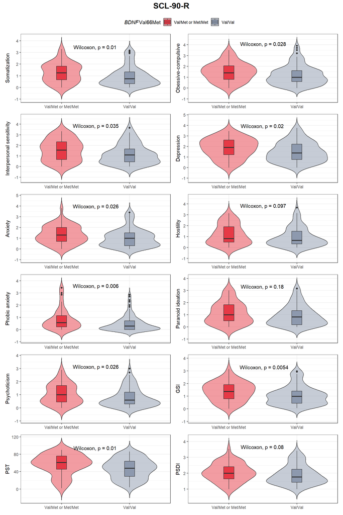

```r
# Prepare a vector with the name of all dimensions so we can iterate through them
scl_dims <- c("Somatization", "Obessive-compulsive", "Interpersonal sensitivity", "Depression", "Anxiety", "Hostility", "Phobic anxiety", "Paranoid ideation", "Psychoticism", "GSI", "PST", "PSDI")
# Select columns that start with scl and end with pre (SCL results prior to therapy)
scl_cols <- c(grep("^scl.*pre$", names(trans), value = TRUE))
# Prepare a list where plots are stored
plots <- list()

# For loop to iterate through all dimensions to produce plots comparing psychopathology dimensions across carrier status categories
for (i in 1:length(scl_cols)){
  p <- ggplot(trans, aes_string(x = "bdnf_val2", y = scl_cols[i], fill = "bdnf_val2")) + # Compare the carrier status with each dimension and color it by carrier status category
      geom_violin(trim = FALSE, alpha = 0.5, position = position_dodge(width = 0.9)) + # Produce a violin plot
      geom_boxplot(width = 0.15, position = position_dodge(width = 0.9)) + # Produce a boxplot inside the violin plot
      stat_compare_means(method = "wilcox.test", label.x = 1.3) + # Add the p-value to the plot
      labs(y = scl_dims[i], fill = expression(paste(italic("BDNF"), "Val66Met"))) + # Add the name of the dimension to the Y-axis title
      scale_fill_manual(values = carriers) + # Color the boxplots with these specific colors
      theme_bw() + # Use the black and white theme
      theme(axis.title.x = element_blank(), legend.position = "none") # Remove the X-axis title and the legend
  # Include the plot to the list of plots
  plots[[i]] <- p # Add the plot to the list of plots
}

final_plot <- wrap_plots(plots, ncol = 2) + # Combine all plots into a 2x6 layout
  plot_annotation(title = "SCL-90-R", theme = theme(plot.title = element_text(hjust = 0.5, size = 17, face = "bold"))) +
  plot_layout(guides = 'collect') & # Collect all legends and use just one
  theme(legend.position = "top") # Put the legend on top

# Show the final plot
final_plot
```

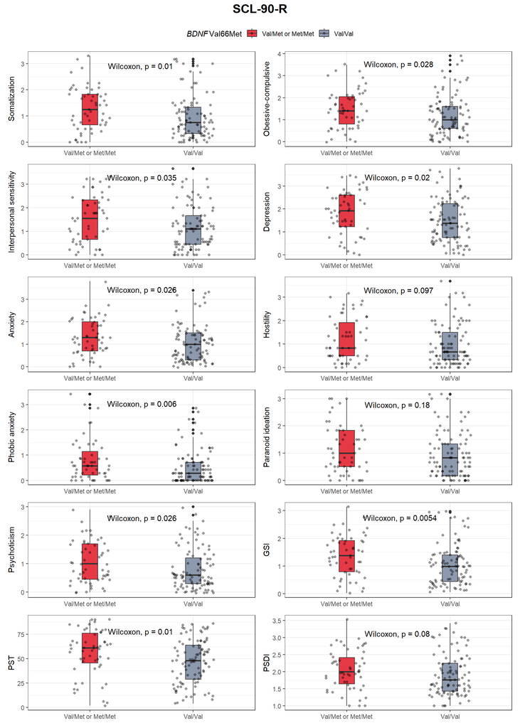

```r
# Prepare a vector with the name of all dimensions so we can iterate through them
scl_dims <- c("Somatization", "Obessive-compulsive", "Interpersonal sensitivity", "Depression", "Anxiety", "Hostility", "Phobic anxiety", "Paranoid ideation", "Psychoticism", "GSI", "PST", "PSDI")
# Select columns that start with scl and end with pre (SCL-90-R results prior to therapy)
scl_cols <- c(grep("^scl.*pre$", names(trans), value = TRUE))
# Prepare a list where plots are stored
plots <- list()

# For loop to iterate through all dimensions to produce plots comparing psychopathology dimensions across carrier status categories
for (i in 1:length(scl_cols)){
  if(scl_cols[i] != "scl_pst_pre"){
    y_max = max(trans[[scl_cols[i]]], na.rm = TRUE)-0.5
  }
  else{
    y_max = max(trans[[scl_cols[i]]], na.rm = TRUE)-15
  }
  p <- ggplot(trans, aes_string(x = "bdnf_val2", y = scl_cols[i], fill = "bdnf_val2")) + # Compare the carrier status with each dimension and color it by carrier status category
      geom_boxplot(width = 0.15, position = position_dodge(width = 0.9)) + # Produce a boxplot
      geom_jitter(shape = 16, alpha = 0.4, position = position_jitter(0.2)) + # Produce a boxplot inside the boxplot
      stat_compare_means(method = "wilcox.test", label.x = 1.3, label.y = y_max) + # Add the p-value to the plot
      labs(y = scl_dims[i], fill = expression(paste(italic("BDNF"), "Val66Met"))) + # Add the name of the dimension to the Y-axis title
      scale_fill_manual(values = carriers) + # Color the boxplots with these specific colors
      theme_bw() + # Use the black and white theme
      theme(axis.title.x = element_blank(), legend.position = "none") # Remove the X-axis title and the legend
  # Include the plot to the list of plots
  plots[[i]] <- p # Add the plot to the list of plots
}

final_plot <- wrap_plots(plots, ncol = 2) + # Combine all plots into a 2x6 layout
  plot_annotation(title = "SCL-90-R", theme = theme(plot.title = element_text(hjust = 0.5, size = 17, face = "bold"))) +
  plot_layout(guides = 'collect') & # Collect all legends and use just one
  theme(legend.position = "top") # Put the legend on top

# Show the final plot
final_plot
```

## Severity

Another objective in this study is to explore the role of severity between Val66Met *BDNF* and EDs and GD. For that, a severity score scale has been computed considering DSM-5 classification criteria.

### Anorexia nervosa

For AN, Val/Val individuals have statistically significant less severe diagnoses than Val/Met and Met/Met individuals. The BMI itself serves as an indicator for this association.

```r
trans %>%
  filter(diagnosis %in% c("AN-R", "AN-P")) %>% # filter by diagnosis and include only AN patients
  select(bdnf_val2, bmi, severity) %>% # select carrier status and variables associated to severity
  tbl_summary(by = bdnf_val2, # divide by carrier status
              missing = "no", # show no missings
              label = list(bmi ~ "BMI (kg/m<sup>2</sup>)", severity ~ "Severity")) %>% # Change the name of the variables
  add_p(test = all_categorical() ~ "chisq.test") %>% # run a Chi-squared test
  bold_labels() %>% # show in bold variable labels
  bold_p(t = 0.05) %>% # show in bold p-values lower than 0.05
  as_gt() %>% #
  gt::fmt_markdown(columns = vars(label)) # Convert markdown syntax to HTML, so the superscript is added
```

| **Characteristic** | **Val/Met or Met/Met** N = 20<sup>1</sup> | **Val/Val** N = 22<sup>1</sup> | **p-value**<sup>2</sup> |
| --- | --- | --- | --- |
| BMI (kg/m<sup>2</sup>) | 15.69 (13.96, 17.04) | 16.89 (16.18, 17.30) | 0.019 |
| Severity |  |  | 0.035 |
| mild | 5 (25%) | 10 (45%) |  |
| moderate | 3 (15%) | 7 (32%) |  |
| severe | 4 (20%) | 4 (18%) |  |
| extreme | 8 (40%) | 1 (4.5%) |  |

<sup>1</sup> Median (Q1, Q3); n (%)  
<sup>2</sup> Wilcoxon rank sum exact test; Pearson’s Chi-squared test

### Bulimia nervosa

```r
trans %>%
  filter(diagnosis == "BN") %>% # filter by diagnosis and include only BN patients
  select(bdnf_val2, vomit_week, severity) %>% # select carrier status and variables associated to severity
  tbl_summary(by = bdnf_val2, # divide by carrier status
              missing = "no", # show no missings
              label = list(vomit_week ~ "Vomits/week", severity ~ "Severity")) %>% # Change the name of the variables
  add_p(test = all_categorical() ~ "chisq.test") %>% # run a Chi-squared test
  bold_labels() %>% # show in bold variable labels
  bold_p(t = 0.05) # show in bold p-values lower than 0.05
```

| **Characteristic** | **Val/Met or Met/Met** N = 20<sup>1</sup> | **Val/Val** N = 34<sup>1</sup> | **p-value**<sup>2</sup> |
| --- | --- | --- | --- |
| Vomits/week | 7 (5, 14) | 9 (2, 17) | >0.9 |
| Severity |  |  | 0.045 |
| mild | 1 (7.1%) | 7 (25%) |  |
| moderate | 6 (43%) | 3 (11%) |  |
| severe | 0 (0%) | 4 (14%) |  |
| extreme | 7 (50%) | 14 (50%) |  |

<sup>1</sup> Median (Q1, Q3); n (%)  
<sup>2</sup> Wilcoxon rank sum test; Pearson’s Chi-squared test

### Gambling disorder

No differences were observed between both groups for GD patients.

```r
trans %>%
  filter(diagnosis == "GD") %>% # filter by diagnosis and include only GD patients
  select(bdnf_val2, sogs_crit, severity) %>% # select carrier status and variables associated to severity
  tbl_summary(by = bdnf_val2, # divide by carrier status
              missing = "no", # show no missings
              label = list(sogs_crit ~ "SOGS criteria", severity ~ "Severity")) %>% # Change the name of the variables
  add_p(test = all_categorical() ~ "chisq.test") %>% # run a Chi-squared test
  bold_labels() %>% # show in bold variable labels
  bold_p(t = 0.05) # show in bold p-values lower than 0.05
```

| **Characteristic** | **Val/Met or Met/Met** N = 26<sup>1</sup> | **Val/Val** N = 56<sup>1</sup> | **p-value**<sup>2</sup> |
| --- | --- | --- | --- |
| SOGS criteria | 11.00 (9.00, 13.00) | 11.00 (9.00, 14.00) | 0.5 |
| Severity |  |  | 0.4 |
| mild | 6 (24%) | 7 (15%) |  |
| moderate | 6 (24%) | 18 (38%) |  |
| severe | 13 (52%) | 22 (47%) |  |
| extreme | 0 (0%) | 0 (0%) |  |

<sup>1</sup> Median (Q1, Q3); n (%)  
<sup>2</sup> Wilcoxon rank sum test; Pearson’s Chi-squared test

### All

Considering all diagnoses, no statistically significant differences were observed.

```r
trans %>%
  select(bdnf_val2, severity) %>% # select carrier status and variables associated to severity
  tbl_summary(by = bdnf_val2, # divide by carrier status
              missing = "no", # show no missings
              label = list(severity ~ "Severity")) %>% # Change the name of the variables
  add_p(test = all_categorical() ~ "chisq.test") %>% # run a Chi-squared test
  bold_labels() %>% # show in bold variable labels
  bold_p(t = 0.05) %>% # show in bold p-values lower than 0.05
  as_gt() %>% #
  gt::fmt_markdown(columns = vars(label)) # Convert markdown syntax to HTML, so the superscript is added
```

| **Characteristic** | **Val/Met or Met/Met** N = 66<sup>1</sup> | **Val/Val** N = 112<sup>1</sup> | **p-value**<sup>2</sup> |
| --- | --- | --- | --- |
| Severity |  |  | 0.5 |
| mild | 12 (20%) | 24 (25%) |  |
| moderate | 15 (25%) | 28 (29%) |  |
| severe | 17 (29%) | 30 (31%) |  |
| extreme | 15 (25%) | 15 (15%) |  |

<sup>1</sup> n (%)  
<sup>2</sup> Pearson’s Chi-squared test

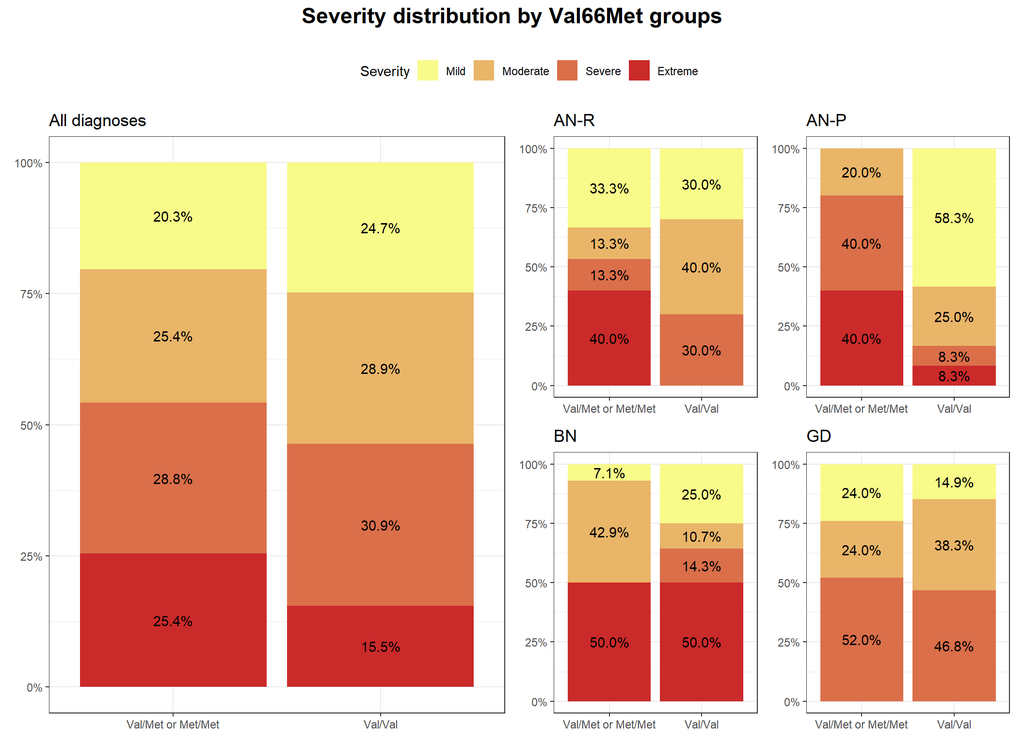

```r
# Prepare a list to store plots
plots <- list()
# Prepare a vector containing the different diagnoses to iterate through them
diagnoses <- c("AN-R", "AN-P", "BN", "GD")

all <- trans %>%
  filter(!is.na(severity)) %>%  # Remove NAs before
  count(severity, bdnf_val2) %>% # Count the combinations of severity scores and Val66Met carrier status
  group_by(bdnf_val2) %>% # Group the counts by carriers status
  mutate(pct = prop.table(n) * 100) %>% # Calculate the percentage
  ggplot() +
  aes(bdnf_val2, pct, fill = severity) + # Compare the proportion of outcomes across carriers and non-carriers and color by outcome
  geom_bar(stat = "identity") + # Make it a bar plot. Add the show.legend argument so later the legend will be the same for all plots
  labs(fill = "Severity", title = "All diagnoses") + # Change the X-axis title, the legend title and the title of the plot in a more appropriate way
  geom_text(aes(label = paste0(sprintf("%1.1f", pct),"%")),
            position = position_stack(vjust = 0.5)) + # Show the percentages in the plot and add the percentage symbol (%) to the labels
  theme_bw() + # Use the black and white theme
  scale_y_continuous(labels = function(x) paste0(x,"%")) + # Add the percentage symbol to the labels from the Y-axis
  scale_fill_manual(values = severity_scores, labels = c("Mild", "Moderate", "Severe", "Extreme")) + # Color the different outcome categories with the specified colors and with the specified labels
  theme(axis.title.x = element_blank(), axis.title.y = element_blank()) # Remove the X-axis and Y-axis titles

# For loop to iterate through all diagnoses to produce plots comparing severity scores proportions across Val66Met groups
for (i in 1:length(diagnoses)){
  p <- trans %>%
    filter(!is.na(severity)) %>%  # Remove NAs before
    filter(diagnosis == diagnoses[i]) %>% # Filter for each diagnosis (as we are going to produce a plot for each diagnosis, we must filter by diagnosis and then generate the plot)
    count(severity, bdnf_val2) %>% # Count the combinations of severity scores and Val66Met groups
    group_by(bdnf_val2) %>% # Group the counts by Val66Met groups
    mutate(pct = prop.table(n) * 100) %>% # Calculate the percentage
    ggplot() +
    aes(bdnf_val2, pct, fill = severity) + # Compare the proportion of outcomes across genotypes and color by outcome
    geom_bar(stat = "identity", show.legend = TRUE) + # Make it a bar plot. Add the show.legend argument so later the legend will be the same for all plots
    labs(x = "Val66Met", fill = "Severity", title = diagnoses[i]) + # Change the X-axis title, the legend title and the title of the plot in a more appropriate way
    geom_text(aes(label = paste0(sprintf("%1.1f", pct),"%")),
              position = position_stack(vjust = 0.5)) + # Show the percentages in the plot and add the percentage symbol (%) to the labels
    theme_bw() + # Use the black and white theme
    scale_y_continuous(labels = function(x) paste0(x,"%")) + # Add the percentage symbol to the labels from the Y-axis
    scale_fill_manual(values = severity_scores, labels = c("Mild", "Moderate", "Severe", "Extreme"), drop = FALSE) + # Color the different outcome categories with the specified colors and with the specified labels
    theme(axis.title.x = element_blank(), axis.title.y = element_blank()) # Remove the X-axis and the Y-axis titles
  plots[[i]] <- p # Add the plot to the list of plots
}

guide_area() + (all + (plots[[1]] + plots[[2]] + plots[[3]] + plots[[4]])) + # Combine all plots into a 2x2 layout
  plot_layout(guides = "collect", nrow = 2, heights = c(1,10)) + # Collect all legends and use just one
  plot_annotation(title = "Severity distribution by Val66Met groups", theme = theme(plot.title = element_text(hjust = 0.5, size = 17, face = "bold"))) & # Set the title in the center, big and bold
  theme(legend.position = "top") # Put the legend on top
```

## Treatment outcome

One of the objectives of this study is to determine if Val66Met affects treatment outcomes. Treatment outcomes can be divided by all possible options (full remission, partial remission, non-remission and dropout) or recategorized into new classifications (good outcome and poor outcome).

```r
# One possibility for treatment outcomes is considering full and partial remissions as good outcomes and non-remissions and dropouts as poor. For that reason, we can create a function to recode the outcome
trans <- trans %>%
  transform(outcome_3 = ifelse(outcome_2 %in% c("full remission", "partial remission"), "good", "poor"))

# Considering the possible outcomes combinations, we can make a comparison table between carrier status and outcomes
trans %>%
  select(bdnf_val2, outcome_2, outcome_3) %>% # select carrier status and outcomes variables
  tbl_summary(by = bdnf_val2, # divide by carrier status
              missing = "no",
              label = list(outcome_2 ~ "Outcome", outcome_3 ~ "Outcome")) %>% # do not add missing counts
  add_p(test = all_categorical() ~ "chisq.test") %>% # run a Chi-squared test
  bold_labels() %>% # show in bold variable labels
  bold_p(t = 0.05) # show in bold p-values lower than 0.05
```

| **Characteristic** | **Val/Met or Met/Met** N = 66<sup>1</sup> | **Val/Val** N = 112<sup>1</sup> | **p-value**<sup>2</sup> |
| --- | --- | --- | --- |
| Outcome |  |  | 0.13 |
| full remission | 26 (39%) | 60 (54%) |  |
| partial remission | 11 (17%) | 21 (19%) |  |
| non-remission | 12 (18%) | 10 (8.9%) |  |
| dropout | 17 (26%) | 21 (19%) |  |
| Outcome |  |  | 0.040 |
| good | 37 (56%) | 81 (72%) |  |
| poor | 29 (44%) | 31 (28%) |  |

<sup>1</sup> n (%)  
<sup>2</sup> Pearson’s Chi-squared test

```r
## outcome (tetratomic) + Val66Met
pwr::ES.h(0.39, 0.54)
```

```
## [1] -0.3019001
```

```r
## outcome (tetratomic) + Val66Met
pwr::ES.h(0.17, 0.19)
```

```
## [1] -0.05207606
```

```r
## outcome (tetratomic) + Val66Met
pwr::ES.h(0.18, 0.089)
```

```
## [1] 0.2704158
```

```r
## outcome (tetratomic) + Val66Met
pwr::ES.h(0.26, 0.19)
```

```
## [1] 0.168088
```

```r
## outcome (dichotomic) + Val66Met
pwr::ES.h(0.56, 0.72)
```

```
## [1] -0.3353088
```

Since there are only 5 people that are Met/Met, participants can be grouped by carrier status.

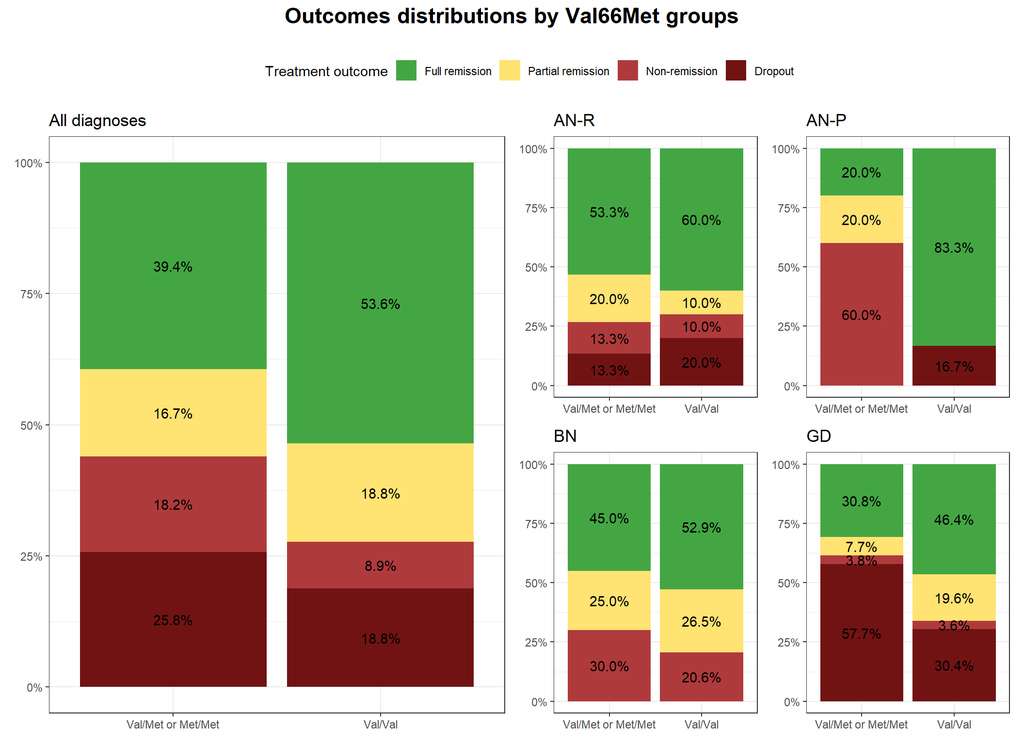

```r
# Prepare a list to store plots
plots <- list()
# Prepare a vector containing the different diagnoses to iterate through them
diagnoses <- c("AN-R", "AN-P", "BN", "GD")

all <- trans %>%
  count(outcome_2, bdnf_val2) %>% # Count the combinations of outcomes and Val66Met carrier status
  group_by(bdnf_val2) %>% # Group the counts by carriers status
  mutate(pct = prop.table(n) * 100) %>% # Calculate the percentage
  ggplot() +
  aes(bdnf_val2, pct, fill = outcome_2) + # Compare the proportion of outcomes across carriers and non-carriers and color by outcome
  geom_bar(stat = "identity") + # Make it a bar plot. Add the show.legend argument so later the legend will be the same for all plots
  labs(fill = "Treatment outcome", title = "All diagnoses") + # Change the X-axis title, the legend title and the title of the plot in a more appropriate way
  geom_text(aes(label = paste0(sprintf("%1.1f", pct),"%")),
            position = position_stack(vjust = 0.5)) + # Show the percentages in the plot and add the percentage symbol (%) to the labels
  theme_bw() + # Use the black and white theme
  scale_y_continuous(labels = function(x) paste0(x,"%")) + # Add the percentage symbol to the labels from the Y-axis
  scale_fill_manual(values = outcome_tetra, labels = c("Full remission", "Partial remission", "Non-remission", "Dropout")) + # Color the different outcome categories with the specified colors and with the specified labels
  theme(axis.title.x = element_blank(), axis.title.y = element_blank()) # Remove the X-axis and Y-axis titles

# For loop to iterate through all diagnoses to produce plots comparing outcomes proportions across genotypes
for (i in 1:length(diagnoses)){
  p <- trans %>%
    filter(diagnosis == diagnoses[i]) %>% # Filter for each diagnosis (as we are going to produce a plot for each diagnosis, we must filter by diagnosis and then generate the plot)
    count(outcome_2, bdnf_val2) %>% # Count the combinations of outcomes and Val66Met genotypes
    group_by(bdnf_val2) %>% # Group the counts by genotypes
    mutate(pct = prop.table(n) * 100) %>% # Calculate the percentage
    ggplot() +
    aes(bdnf_val2, pct, fill = outcome_2) + # Compare the proportion of outcomes across genotypes and color by outcome
    geom_bar(stat = "identity", show.legend = TRUE) + # Make it a bar plot. Add the show.legend argument so later the legend will be the same for all plots
    labs(x = "Genotypes", fill = "Treatment outcome", title = diagnoses[i]) + # Change the X-axis title, the legend title and the title of the plot in a more appropriate way
    geom_text(aes(label = paste0(sprintf("%1.1f", pct),"%")),
              position = position_stack(vjust = 0.5)) + # Show the percentages in the plot and add the percentage symbol (%) to the labels
    theme_bw() + # Use the black and white theme
    scale_y_continuous(labels = function(x) paste0(x,"%")) + # Add the percentage symbol to the labels from the Y-axis
    scale_fill_manual(values = outcome_tetra, labels = c("Full remission", "Partial remission", "Non-remission", "Dropout"), drop = FALSE) + # Color the different outcome categories with the specified colors and with the specified labels
    theme(axis.title.x = element_blank(), axis.title.y = element_blank()) # Remove the X-axis and the Y-axis titles
  plots[[i]] <- p # Add the plot to the list of plots
}

guide_area() + (all + (plots[[1]] + plots[[2]] + plots[[3]] + plots[[4]])) + # Combine all plots into a 2x2 layout
  plot_layout(guides = "collect", nrow = 2, heights = c(1,10)) + # Collect all legends and use just one
  plot_annotation(title = "Outcomes distributions by Val66Met groups", theme = theme(plot.title = element_text(hjust = 0.5, size = 17, face = "bold"))) & # Set the title in the center, big and bold
  theme(legend.position = "top") # Put the legend on top
```

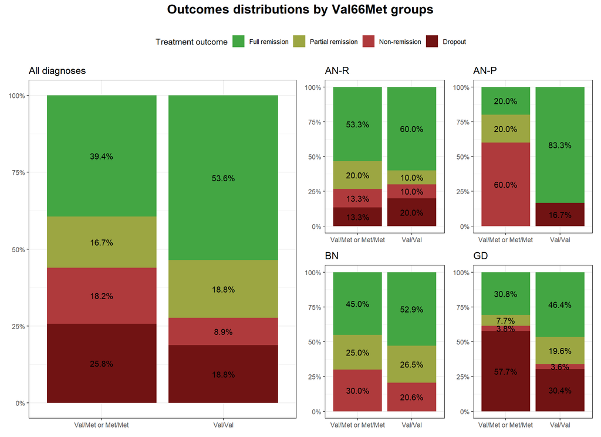

```r
# Prepare a list to store plots
plots <- list()

# The following figure shows the distribution of treatment outcomes (using the complete variable but painting as a dichotomic variable)
all <- trans %>%
  count(outcome_2, bdnf_val2) %>% # Count the combinations of outcomes and Val66Met carrier status
  group_by(bdnf_val2) %>% # Group the counts by carrier status
  mutate(pct = prop.table(n) * 100) %>% # Calculate the percentage
  ggplot() +
  aes(bdnf_val2, pct, fill = outcome_2) + # Compare the proportion of outcomes across carrier status and color by outcome
  geom_bar(stat = "identity") + # Make it a bar plot. Add the show.legend argument so later the legend will be the same for all plots
  labs(fill = "Treatment outcome", title = "All diagnoses") + # Change the X-axis title, the legent title and the title of the plot in a more appropriate way
  geom_text(aes(label = paste0(sprintf("%1.1f", pct),"%")),
            position = position_stack(vjust = 0.5)) + # Show the percentages in the plot and add the percentage symbol (%) to the labels
  theme_bw() + # black and white theme
  scale_y_continuous(labels = function(x) paste0(x,"%")) + # Add the percentage symbol to the labels from the Y-axis
  scale_fill_manual(values = outcome_dicho, labels = c("Full remission", "Partial remission", "Non-remission", "Dropout")) + # Color the different outcome categories with the specified colors and with the specified labels
  theme(axis.title.x = element_blank(), axis.title.y = element_blank()) # Remove the X-axis and the Y-axis titles

# For loop to iterate through all diagnoses to produce plots comparing outcomes proportions across genotypes
for (i in 1:length(diagnoses)){
  p <- trans %>%
    filter(diagnosis == diagnoses[i]) %>% # Filter for each diagnosis (as we are going to produce a plot for each diagnosis, we must filter by diagnosis and then generate the plot)
    count(outcome_2, bdnf_val2) %>% # Count the combinations of outcomes and Val66Met carrier status
    group_by(bdnf_val2) %>% # Group the counts by carrier status
    mutate(pct = prop.table(n) * 100) %>% # Calculate the percentage
    ggplot() +
    aes(bdnf_val2, pct, fill = outcome_2) + # Compare the proportion of outcomes across non-carriers and carriers and color by outcome
    geom_bar(stat = "identity", show.legend = TRUE) + # Make it a bar plot. Add the show.legend argument so later the legend will be the same for all plots
    labs(fill = "Treatment outcome", title = diagnoses[i]) + # Change the X-axis title, the legend title and the title of the plot in a more appropriate way
    geom_text(aes(label = paste0(sprintf("%1.1f", pct),"%")),
              position = position_stack(vjust = 0.5)) + # Show the percentages in the plot and add the percentage symbol (%) to the labels
    theme_bw() + # Use the black and white theme
    scale_y_continuous(labels = function(x) paste0(x,"%")) + # Add the percentage symbol to the labels from the Y-axis
    scale_fill_manual(values = outcome_dicho, labels = c("Full remission", "Partial remission", "Non-remission", "Dropout"), drop = FALSE) + # Color the different outcome categories with the specified colors and with the specified labels
    theme(axis.title.x = element_blank(), axis.title.y = element_blank()) # Remove the X-axis and the Y-axis titles
  plots[[i]] <- p # Add the plot to the list of plots
}

guide_area() + (all + (plots[[1]] + plots[[2]] + plots[[3]] + plots[[4]])) + # Combine all plots into a 2x2 layout
  plot_layout(guides = "collect", nrow = 2, heights = c(1,10)) + # Collect all legends and use just one
  plot_annotation(title = "Outcomes distributions by Val66Met groups", theme = theme(plot.title = element_text(hjust = 0.5, size = 17, face = "bold"))) & # Set the title in the center, big and bold
  theme(legend.position = "top") # Put the legend on top
```